# Sleep_Disorder_Classification

Buse Uzun

2025-07-22

# Aim of the project

The aim of this project is to see how daily habits of participants changes their sleep healths. The dataset contains variables such as gender, age, occupation, sleep duration, quality of sleep etc. The dependent variable is chosen as sleep disorder variable which shows whether the participant has insomnia, sleep apnea or none.

What is insomnia and sleep apnea?

Insomnia is having trouble to fall asleep or keep sleeping. Sleep apnea is having breathing problems while sleeping where it repeatedly stops and begins.

## Source of the data:

This dataset is taken from kaggle: https://www.kaggle.com/datasets/uom190346a/sleep-health-and-lifestyle-dataset/data

# Creating Missing Values

As the dataset does not contain missing values, we need to generate missing completely at random (MCAR) variables.

```r
original_sleep = read.csv("Sleep_health_and_lifestyle_dataset.csv")
```

```r
set.seed(412)

#create 10 percent missingness (MCAR)
#sleep_mcar = delete_MCAR(ds = original_sleep, p = 0.1)

#colSums(is.na(sleep_mcar))

#write.csv(sleep_mcar, 'sleep_health_missing.csv', row.names = FALSE)
```

# Importing the Data

```r
sleep <- read.csv("sleep_health_missing.csv")
```

```r
sum(is.na(sleep))
```

```
## [1] 481
```

```r
head(sleep)
```

```
##   Person.ID Gender Age           Occupation Sleep.Duration Quality.of.Sleep
## 1         1   Male  27    Software Engineer            6.1                6
## 2         2   Male  28               Doctor            6.2                6
## 3        NA   Male  28               Doctor            6.2                6
## 4         4   Male  28 Sales Representative             NA                4
## 5         5   Male  28 Sales Representative            5.9                4
## 6         6   Male  28    Software Engineer             NA                4
##   Physical.Activity.Level Stress.Level BMI.Category Blood.Pressure Heart.Rate
## 1                      42            6   Overweight         126/83         77
## 2                      60            8       Normal         125/80         75
## 3                      60            8       Normal         125/80         75
## 4                      30            8        Obese           <NA>         85
## 5                      30            8         <NA>         140/90         85
## 6                      30            8        Obese         140/90         85
##   Daily.Steps Sleep.Disorder
## 1        4200           None
## 2       10000           None
## 3       10000           None
## 4        3000    Sleep Apnea
## 5        3000    Sleep Apnea
## 6        3000       Insomnia
```

```r
dim(sleep)
```

```
## [1] 374  13
```

From the output of the dimension, we can see that the dataset has 374 observations for 13 variables.

# Data Cleaning and Tidying

Before moving forward, column names can be altered for ease of use.

```r
colnames(sleep) <-c("Person_ID","Gender","Age","Occupation","Sleep_Duration","Sleep_Quality","Physical_Activity_Level","Stress_Level","BMI_Category","Blood_Pressure","Heart_Rate","Daily_Steps","Sleep_Disorder")

colnames(sleep)
```

```
##  [1] "Person_ID"               "Gender"
##  [3] "Age"                     "Occupation"
##  [5] "Sleep_Duration"          "Sleep_Quality"
##  [7] "Physical_Activity_Level" "Stress_Level"
##  [9] "BMI_Category"            "Blood_Pressure"
## [11] "Heart_Rate"              "Daily_Steps"
## [13] "Sleep_Disorder"
```

Persont_ID: Given IDs to identify participants

Age: Age of the participants

Gender: Female, Male

Occupation: Occupation of the participant

Sleep_Duration: Sleep hours of participants per day

Sleep_Quality: Subjective rating of sleep quality (1-10 scale)

Physical_Activity_Level: The amount of physical activity of participants in minutes

Stress_Level: Subjective stress level of participants (1-10 scale)

Blood_Pressure: Blood pressure of the participants. Computed by dividing systolic pressure by diastolic pressure

Heart_Rate: Resting heart rate of the participants in beats per minute (bpm)

Daily_Steps: The number of daily steps of participants

Sleep_Disorder: Shows whether the participant has insomnia, sleep apnea ar none

Now, we can check if the variables are formatted correctly. Classes of variables can be checked as following,

```r
str(sleep)
```

```
## 'data.frame':    374 obs. of  13 variables:
##  $ Person_ID              : int  1 2 NA 4 5 6 NA 8 NA 10 ...
##  $ Gender                 : chr  "Male" "Male" "Male" "Male" ...
##  $ Age                    : int  27 28 28 28 28 28 29 29 29 NA ...
##  $ Occupation             : chr  "Software Engineer" "Doctor" "Doctor" "Sales Representative" ...
##  $ Sleep_Duration         : num  6.1 6.2 6.2 NA 5.9 NA 6.3 7.8 7.8 7.8 ...
##  $ Sleep_Quality          : int  6 6 6 4 4 4 6 7 7 7 ...
##  $ Physical_Activity_Level: int  42 60 60 30 30 30 40 75 75 75 ...
##  $ Stress_Level           : int  6 8 8 8 8 8 7 6 6 6 ...
##  $ BMI_Category           : chr  "Overweight" "Normal" "Normal" "Obese" ...
##  $ Blood_Pressure         : chr  "126/83" "125/80" "125/80" NA ...
##  $ Heart_Rate             : int  77 75 75 85 85 85 NA 70 70 70 ...
##  $ Daily_Steps            : int  4200 10000 10000 3000 3000 3000 NA 8000 8000 8000 ...
##  $ Sleep_Disorder         : chr  "None" "None" "None" "Sleep Apnea" ...
```

```r
summary(sleep)
```

```
##    Person_ID      Gender               Age         Occupation
##  Min.   :  1   Length:374         Min.   :27.00   Length:374
##  1st Qu.: 96   Class :character   1st Qu.:35.00   Class :character
##  Median :191   Mode  :character   Median :43.00   Mode  :character
##  Mean   :190                      Mean   :42.27
##  3rd Qu.:283                      3rd Qu.:50.00
##  Max.   :374                      Max.   :59.00
##  NA's   :37                       NA's   :37
##  Sleep_Duration  Sleep_Quality   Physical_Activity_Level  Stress_Level
##  Min.   :5.800   Min.   :4.000   Min.   :30.00           Min.   :3.000
##  1st Qu.:6.400   1st Qu.:6.000   1st Qu.:45.00           1st Qu.:4.000
##  Median :7.200   Median :7.000   Median :60.00           Median :5.000
##  Mean   :7.128   Mean   :7.285   Mean   :59.49           Mean   :5.362
##  3rd Qu.:7.800   3rd Qu.:8.000   3rd Qu.:75.00           3rd Qu.:7.000
##  Max.   :8.500   Max.   :9.000   Max.   :90.00           Max.   :8.000
##  NA's   :37      NA's   :37      NA's   :37              NA's   :37
##  BMI_Category       Blood_Pressure       Heart_Rate     Daily_Steps
##  Length:374         Length:374         Min.   :65.00   Min.   : 3000
##  Class :character   Class :character   1st Qu.:68.00   1st Qu.: 6000
##  Mode  :character   Mode  :character   Median :70.00   Median : 7000
##                                        Mean   :70.23   Mean   : 6821
##                                        3rd Qu.:72.00   3rd Qu.: 8000
##                                        Max.   :86.00   Max.   :10000
##                                        NA's   :37      NA's   :37
##  Sleep_Disorder
##  Length:374
##  Class :character
##  Mode  :character
##
##
##
##
```

Variables such as Gender, BMI_Category, Sleep_Disorder, and Occupation should be transformed to factors (Sleep quality and stress level should be factors too, but they will be handled in the following part.). Person_ID variable is unnecessary so it is removed.

```r
sleep$Gender <- as.factor(sleep$Gender)
#sleep$Sleep_Quality <- as.factor(sleep$Sleep_Quality)
#sleep$Stress_Level <- as.factor(sleep$Stress_Level)
sleep$BMI_Category <- as.factor(sleep$BMI_Category)
sleep$Sleep_Disorder <- as.factor(sleep$Sleep_Disorder)
sleep$Occupation <- as.factor(sleep$Occupation)
sleep$Person_ID <- NULL
```

```r
str(sleep)
```

```
## 'data.frame':    374 obs. of  12 variables:
##  $ Gender                 : Factor w/ 2 levels "Female","Male": 2 2 2 2 2 2 2 2 2 NA ...
##  $ Age                    : int  27 28 28 28 28 28 29 29 29 NA ...
##  $ Occupation             : Factor w/ 11 levels "Accountant","Doctor",..: 10 2 2 7 7 10 11 2 2 2 ...
##  $ Sleep_Duration         : num  6.1 6.2 6.2 NA 5.9 NA 6.3 7.8 7.8 7.8 ...
##  $ Sleep_Quality          : int  6 6 6 4 4 4 6 7 7 7 ...
##  $ Physical_Activity_Level: int  42 60 60 30 30 30 40 75 75 75 ...
##  $ Stress_Level           : int  6 8 8 8 8 8 7 6 6 6 ...
##  $ BMI_Category           : Factor w/ 4 levels "Normal","Normal Weight",..: 4 1 1 3 NA 3 3 1 1 1 ...
##  $ Blood_Pressure         : chr  "126/83" "125/80" "125/80" NA ...
##  $ Heart_Rate             : int  77 75 75 85 85 85 NA 70 70 70 ...
##  $ Daily_Steps            : int  4200 10000 10000 3000 3000 3000 NA 8000 8000 8000 ...
##  $ Sleep_Disorder         : Factor w/ 3 levels "Insomnia","None",..: 2 2 2 3 3 1 1 2 2 2 ...
```

```r
summary(sleep)
```

```
##     Gender         Age             Occupation Sleep_Duration  Sleep_Quality
##  Female:164   Min.   :27.00   Nurse     :64   Min.   :5.800   Min.   :4.000
##  Male  :173   1st Qu.:35.00   Doctor    :63   1st Qu.:6.400   1st Qu.:6.000
##  NA's  : 37   Median :43.00   Engineer  :57   Median :7.200   Median :7.000
##               Mean   :42.27   Lawyer    :39   Mean   :7.128   Mean   :7.285
##               3rd Qu.:50.00   Accountant:36   3rd Qu.:7.800   3rd Qu.:8.000
##               Max.   :59.00   (Other)   :78   Max.   :8.500   Max.   :9.000
##               NA's   :37      NA's      :37   NA's   :37      NA's   :37
##  Physical_Activity_Level  Stress_Level          BMI_Category Blood_Pressure
##  Min.   :30.00           Min.   :3.000   Normal       :175   Length:374
##  1st Qu.:45.00           1st Qu.:4.000   Normal Weight: 19   Class :character
##  Median :60.00           Median :5.000   Obese        :  9   Mode  :character
##  Mean   :59.49           Mean   :5.362   Overweight   :134
##  3rd Qu.:75.00           3rd Qu.:7.000   NA's         : 37
##  Max.   :90.00           Max.   :8.000
##  NA's   :37              NA's   :37
##    Heart_Rate     Daily_Steps        Sleep_Disorder
##  Min.   :65.00   Min.   : 3000   Insomnia   : 72
##  1st Qu.:68.00   1st Qu.: 6000   None       :192
##  Median :70.00   Median : 7000   Sleep Apnea: 73
##  Mean   :70.23   Mean   : 6821   NA's       : 37
##  3rd Qu.:72.00   3rd Qu.: 8000
##  Max.   :86.00   Max.   :10000
##  NA's   :37      NA's   :37
```

Some of the variables need to be altered further before doing any exploration or analysis. First, BMI category should be submerged to Normal Weight and Overweight. Sleep quality and stress level can be categorized further to show qualities; they are actually showing scores between 1-10, but they will be categorized in the following part as there are many missing scores. Sleep disorder can be submerged to binary by classifying not having sleep disorders as 0, and having sleep disorders as 1. Also, the blood pressure column is taken as character because it is stored as “Systolic Blood Pressure/Diastolic Blood Pressure”.

**BMI Category:**

Here, the categories are merged to normal weight and overveight.

```r
sleep <- sleep %>%
  mutate(BMI_Category = case_when(
    BMI_Category %in% c("Normal", "Normal Weight") ~ "Normal Weight",
    BMI_Category %in% c("Overweight", "Obese") ~ "Overweight",
    TRUE ~ NA_character_
  )) %>%
  mutate(BMI_Category = factor(BMI_Category, levels = c("Normal Weight", "Overweight")))
```

**Sleep Quality:**

```r
sleep <- sleep %>%
  mutate(Sleep_Quality = case_when(
    Sleep_Quality < 5 ~ "Low",
    Sleep_Quality <= 6 ~ "Moderate",
    Sleep_Quality <= 8 ~ "Good",
    Sleep_Quality > 8 ~ "Very Good",
    TRUE ~ NA_character_
  )) %>%
  mutate(Sleep_Quality = factor(Sleep_Quality, levels = c("Low", "Moderate", "Good","Very Good")))
```

Since generally used Pitsburg Sleep Quality Index ranges from 0-21 and this dataset ranges from 1-10, it was not possible to use it. A 4-level classification informed by sleep health literature was adapted.

*Reference:*

Hirshkowitz, M., et al. (2015). National Sleep Foundation’s Sleep Time Duration Recommendations: Methodology and Results Summary. Sleep Health.

**Stress Level:**

Stress level shows the scores from 1-10, it was modified to 3 categories which are low for 1-3, moderate for 4-6, and high for 7-10.

```r
sleep <- sleep %>%
  mutate(Stress_Level = case_when(
    Stress_Level <= 3 ~ "Low",
    Stress_Level <= 6 ~ "Moderate",
    Stress_Level >= 7 ~ "High",
    TRUE ~ NA_character_
  )) %>%
  mutate(Stress_Level = factor(Stress_Level, levels = c("Low", "Moderate", "High")))
```

*Reference:*

Cohen, S., Kamarck, T., & Mermelstein, R. (1983). A global measure of perceived stress. Journal of Health and Social Behavior, 24(4), 385–396.

**Sleep Disorder:**

Sleep disorder was merged into 2 categories to represent no sleep disorders and sleep disorders.

```r
sleep <- sleep %>%
  mutate(Sleep_Disorder = case_when(
    Sleep_Disorder %in% c("Insomnia", "Sleep Apnea") ~ "Yes",
    Sleep_Disorder == "None" ~ "No",
    TRUE ~ NA_character_
  ))

sleep$Sleep_Disorder <- factor(sleep$Sleep_Disorder, levels = c("No", "Yes"))
```

**Blood Pressure:**

First I separated the blood pressure to systolic and diastolic columns and then categorized them based on American College of Cardiology and the American Heart Association’s 2017 Guideline for Blood Pressure in Adults based on stages.

Low: Systolic<90, Diastolic<60 (no observation)

Moderate: Systolic<129, Diastolic<80 (I combined normal and elevated for simplification))

High Stage 1: 130<Systolic<139 or 80<Diastolic<89

High Stage 2: Systolic>=140 or Diastolic>=90

Hypertensive Crisis: Systolic>=180 and/or Diastolic>=120 (no observation)

```r
sleep <- sleep %>%
  separate(Blood_Pressure, into = c("Systolic", "Diastolic"), sep = "/", convert = TRUE) %>%
    mutate(Blood_Pressure_C = case_when(
    Systolic < 90 | Diastolic < 60 ~ "Low",
    Systolic < 130 & Diastolic < 80 ~ "Moderate",
    (Systolic >= 130 & Systolic <= 139) | (Diastolic >= 80 & Diastolic <= 89) ~ "High Stage 1",
    (Systolic >= 140 & Systolic < 180) | (Diastolic >= 90 & Diastolic < 120) ~ "High Stage 2",
    Systolic >= 180 | Diastolic >= 120 ~ "Hypertensive Crisis",
    TRUE ~ NA_character_
  ))
```

```r
sleep$Blood_Pressure_C <- as.factor(sleep$Blood_Pressure_C)
sleep$Systolic <- NULL
sleep$Diastolic <- NULL
```

*Reference:*

2017 ACC/AHA/AAPA/ABC/ACPM/AGS/APhA/ASH/ASPC/NMA/PCNA Guideline for the Prevention, Detection, Evaluation, and Management of High Blood Pressure in Adults Published by: American College of Cardiology (ACC) & American Heart Association (AHA) Journal: Hypertension, Volume 71, Issue 6, June 2018 DOI: 10.1161/HYP.0000000000000065

Now, summary and standard deviations can be checked:

```r
summary(sleep)
```

```
##     Gender         Age             Occupation Sleep_Duration    Sleep_Quality
##  Female:164   Min.   :27.00   Nurse     :64   Min.   :5.800   Low      :  5
##  Male  :173   1st Qu.:35.00   Doctor    :63   1st Qu.:6.400   Moderate :104
##  NA's  : 37   Median :43.00   Engineer  :57   Median :7.200   Good     :166
##               Mean   :42.27   Lawyer    :39   Mean   :7.128   Very Good: 62
##               3rd Qu.:50.00   Accountant:36   3rd Qu.:7.800   NA's     : 37
##               Max.   :59.00   (Other)   :78   Max.   :8.500
##               NA's   :37      NA's      :37   NA's   :37
##  Physical_Activity_Level   Stress_Level        BMI_Category   Heart_Rate
##  Min.   :30.00           Low     : 63   Normal Weight:194   Min.   :65.00
##  1st Qu.:45.00           Moderate:171   Overweight   :143   1st Qu.:68.00
##  Median :60.00           High    :103   NA's         : 37   Median :70.00
##  Mean   :59.49           NA's    : 37                       Mean   :70.23
##  3rd Qu.:75.00                                              3rd Qu.:72.00
##  Max.   :90.00                                              Max.   :86.00
##  NA's   :37                                                 NA's   :37
##   Daily_Steps    Sleep_Disorder     Blood_Pressure_C
##  Min.   : 3000   No  :192       High Stage 1:237
##  1st Qu.: 6000   Yes :145       High Stage 2: 59
##  Median : 7000   NA's: 37       Moderate    : 41
##  Mean   : 6821                  NA's        : 37
##  3rd Qu.: 8000
##  Max.   :10000
##  NA's   :37
```

```
## standard deviation of Age: 8.779522
```

```
## standard deviation of Sleep Duration: 0.8003388
```

```
## standard deviation of Physical Activity Level: 20.95192
```

```
## standard deviation of Heart Rate: 4.183471
```

```
## standard deviation of Daily Steps: 1619.776
```

From the summary statistics we can investigate the variables further. It can be observed that there are 164 female, 173 male and 37 NA values.

Minimum age of the participants is 27 while the maximum age is 59, mean age is 42.27 and the standard deviation is 8.78.

There are 11 different occupations of participants such as nurse, doctor, engineer etc.

Sleep duration of the participants ranges between 5.8 to 8.5 hours, average sleeping hour is 7.13, and the median is 7.2. The closeness of the mean and the median can be an indicator of normal distribution of the variable. Also, its standard deviation is 0.8.

Sleep quality of the participants are mostly good with 166 people, it is followed by moderate sleep quality with 104 people, very good sleep quality with 62 people, and lastly low sleep quality with 5 people.

Lowest engaged physical activity is 30 minutes, and the greatest is 90 minutes. Mean of the physical activity level is 59.49 minutes and the standard deviation is 20.95.

The most chosen stress level by participants was moderate with 171 people, it was followed by high level with 103, and low level with 63 people.

When BMI categories are inspected, 194 were normal weight and 143 were overweight.

The blood pressure categories are either high stage 1 or 2 and moderate. Most of the participants fall into high stage 1 category.

Minimum heart rate of attendants is 65 and the maximum is 86, average heart rate is 70.23 and the standard deviation is 4.18.

Daily steps variable ranges between 3000 to 10000 with the median of 7000 and the average of 6821. The standard deviation of daily steps is 1619.776

Finally, the sleep disorder column which is the dependent variable has 192 people who do not have a sleep disorder and 145 people who do have a sleep disorder (either insomnia or sleep apnea).

Each variable had 37 NA values.

# Exploratory Data Analysis

## Research Questions:

#### Q1: How are the ages of participants distributed?

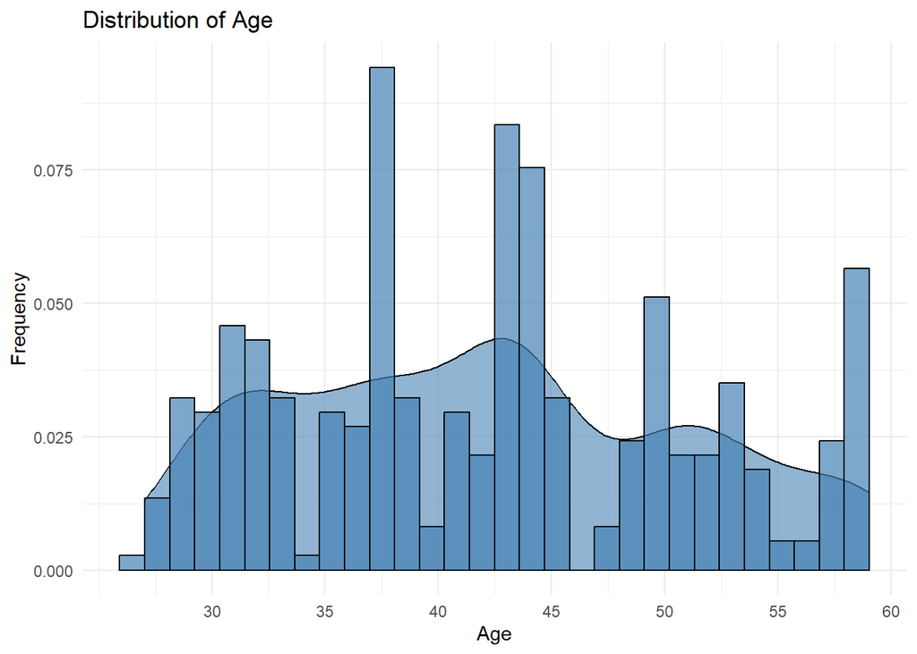

```r
ggplot(sleep, aes(x = Age)) +
  geom_density(fill = "steelblue", alpha = 0.6) +
  geom_histogram(aes(y = after_stat(density)), bins = 30,fill = "steelblue", color = "black", alpha = 0.7) +
  labs(
    title = "Distribution of Age",
    x = "Age",
    y = "Frequency"
  ) +
  scale_x_continuous(breaks = seq(30, 70, by =5))+
  theme_minimal()
```

#### Q2: How much missing data is there?

```r
sum(is.na(sleep))
```

```
## [1] 444
```

There are 444 missing values in the data in total, these will be handled later on.

#### Q3: What are the relationship between numerical values in the data?

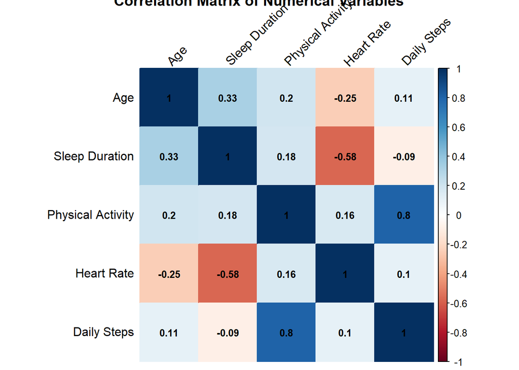

```r
numeric_variables <- sleep[, sapply(sleep, is.numeric)]
colnames(numeric_variables) <- c("Age", "Sleep Duration", "Physical Activity","Heart Rate", "Daily Steps")
correlation_matrix <- cor(numeric_variables, use = "na.or.complete")

corrplot(correlation_matrix, method = "color",
         addCoef.col = "black",
         tl.col = "black",
         tl.srt = 45,
         number.cex = 0.8,
         main = "Correlation Matrix of Numerical Variables")
```

#### Q4: What is the relationship between sleep disorders and physical activity level?

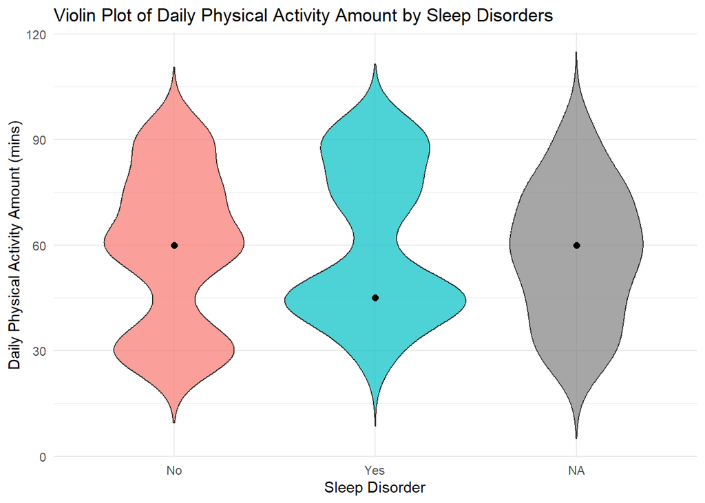

```r
ggplot(sleep, aes(x = Sleep_Disorder, y = Physical_Activity_Level, fill = Sleep_Disorder)) +
  geom_violin(trim = FALSE, alpha = 0.7) +
  stat_summary(fun = median, geom = "point", size = 2, color = "black") +
  labs(title = "Violin Plot of Daily Physical Activity Amount by Sleep Disorders",
       x = "Sleep Disorder",
       y = "Daily Physical Activity Amount (mins)") +
  theme_minimal() +
  theme(legend.position = "none")
```

From the violin plots it can be observed that both not having a sleep disorder and having a sleep disorder with respect to the number of minutes participants engaged in physical activities is not normal. Attendants who has a sleep disorder has a lower median in physical activity amount around 45 minutes. The median of physical activity is 60 minutes for participants who do not have a sleep disorder. NA values in sleep disorder seems to have unimodal distribution.

#### Q5:What is the relationship between BMI categories and stress levels of attendants?

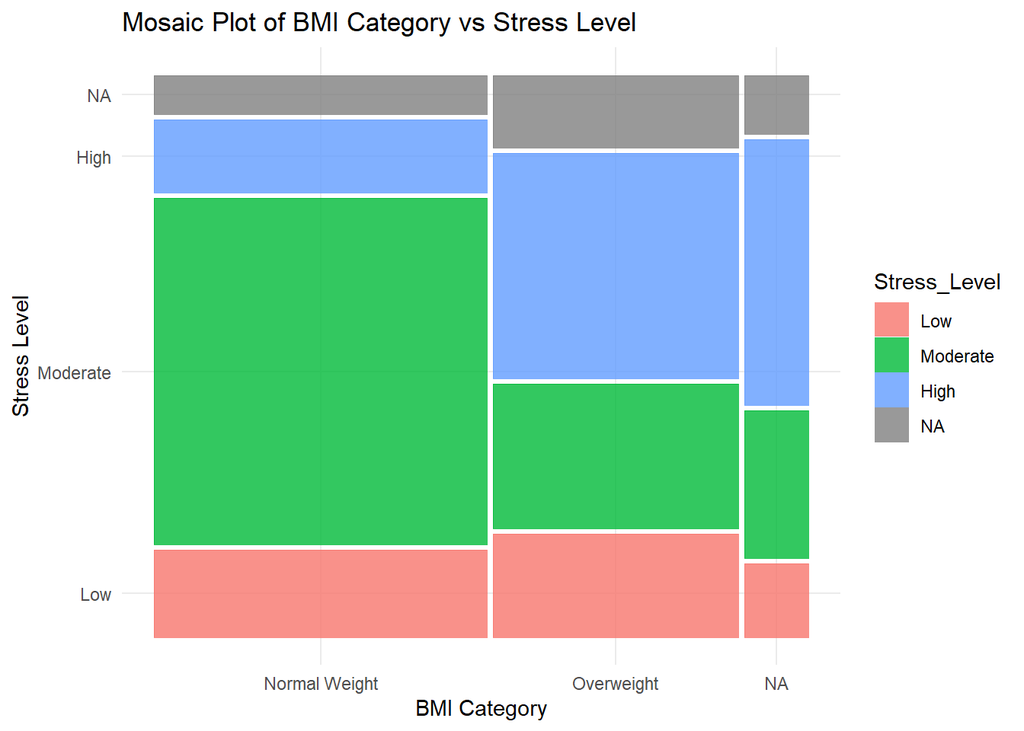

```r
library(ggmosaic)
ggplot(sleep) +
  geom_mosaic(aes(weight = 1, x = product(BMI_Category), fill = Stress_Level)) +
  labs(title = "Mosaic Plot of BMI Category vs Stress Level",
       x = "BMI Category",
       y = "Stress Level") +
  theme_minimal()
```

From the mosaic plot it is seen that more overweight individuals tend to have high stress level than normal weighted ones. Moderate stress type seems to be the opposite, more normal weighted people are in this category than overweight ones.

#### Q6: How does the relationship of physical activity level, heart rate, sleep disorder, and stress level look like?

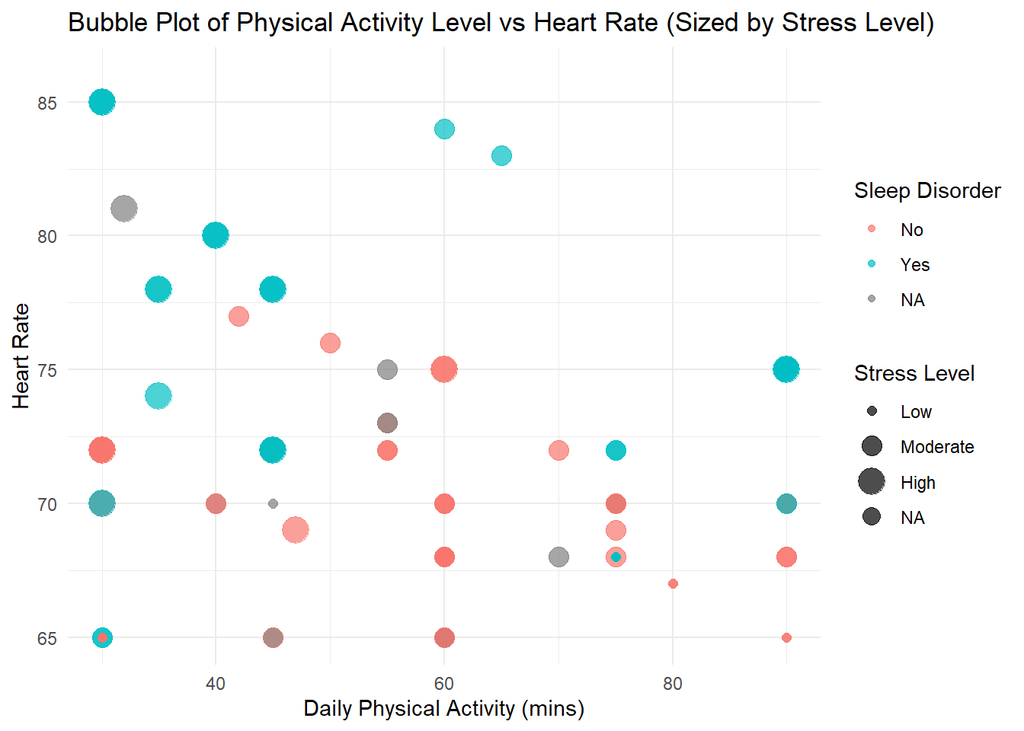

```r
ggplot(sleep, aes(x = Physical_Activity_Level, y = Heart_Rate, color = Sleep_Disorder, size = Stress_Level)) +
  geom_point(alpha = 0.7) +
  labs(title = "Bubble Plot of Physical Activity Level vs Heart Rate (Sized by Stress Level)",
       x = "Daily Physical Activity (mins)",
       y = "Heart Rate",
       size = "Stress Level",
       color = "Sleep Disorder") +
  theme_minimal()
```

From the bubble plot, the size of the bubbles shows stress levels, it can be observed that as the heart rate increases, stress levels and having a sleep disorder subtly increase as well. It seems that people with lower daily physical activity has sleep disorders and their heart rate seems to be on the higher side. It does not look like there is a linear relationship between heart rate and daily physical activity.

#### Q7: Is there any outliers in heart rates of participants?

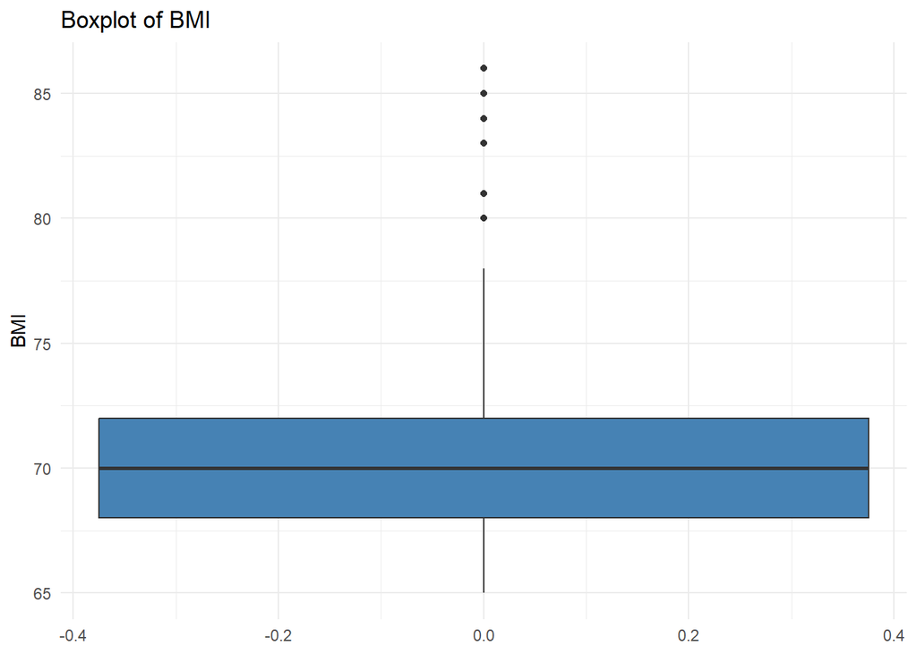

```r
ggplot(sleep, aes(y = Heart_Rate)) +
  geom_boxplot(fill = "steelblue") +
  labs(title = "Boxplot of BMI", y = "BMI") +
  theme_minimal()
```

There does seem to be some outliers in heart rate variable, its distribution looks a bit symmetric.

#### Q8: How does the relationship of daily steps and sleep duration look like based on gender?

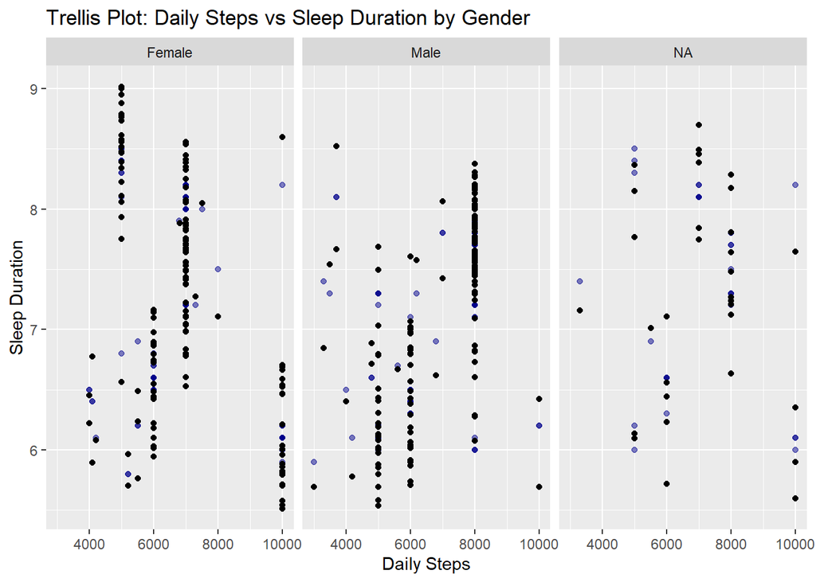

```r
ggplot(sleep, aes(x = Daily_Steps, y = Sleep_Duration)) +
  facet_wrap(~ Gender) +
  geom_point(color = "darkblue", alpha=0.5) +
  geom_jitter(width=0.9, height=0.6)+
  labs(title = "Trellis Plot: Daily Steps vs Sleep Duration by Gender",
       x = "Daily Steps",
       y = "Sleep Duration")
```

From the faceted plots with respect to gender, there does not seem to be any relationship between daily steps and sleep duration with respect to gender. There might be very little positive correlation for females.

#### Q9: What is the relationship between occupation and gender?

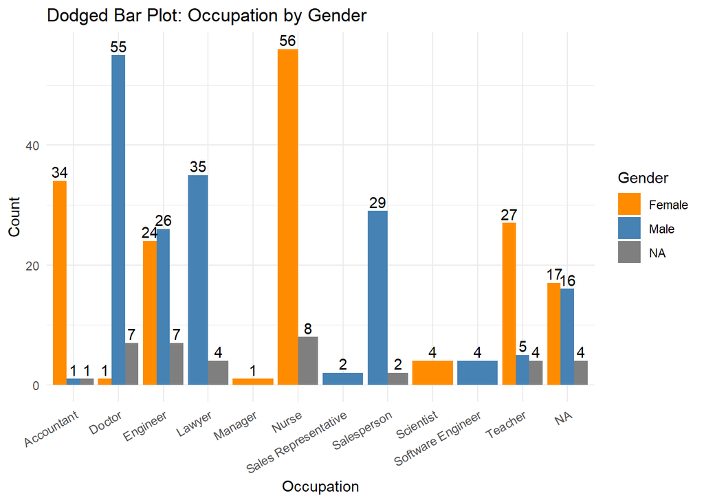

```r
ggplot(sleep, aes(x = Occupation, fill = Gender)) +
  geom_bar(position = position_dodge()) +
  geom_text(stat = "count", aes(label = after_stat(count)),
            position = position_dodge(width = 0.9), vjust = -0.3) +
  scale_fill_manual(values = c("darkorange", "steelblue")) +
  labs(title = "Dodged Bar Plot: Occupation by Gender",
       x = "Occupation",
       y = "Count",
       fill = "Gender") +
  scale_x_discrete(guide = guide_axis(angle = 30))+
  theme_minimal()
```

From the dodged bar plot, we can see that occupations like manager, nurse, and scientist only have female participants while lawyer, sales person and software engineer only have male participants. The most missingness is seen in nurses.

# Exploration of Missingness Mechanism

First, the missingness pattern should be investigated.

```r
# Check where missing values are
miss_var_summary(sleep)
```

```
## # A tibble: 12 × 3
##    variable                n_miss pct_miss
##    <chr>                    <int>    <num>
##  1 Gender                      37     9.89
##  2 Age                         37     9.89
##  3 Occupation                  37     9.89
##  4 Sleep_Duration              37     9.89
##  5 Sleep_Quality               37     9.89
##  6 Physical_Activity_Level     37     9.89
##  7 Stress_Level                37     9.89
##  8 BMI_Category                37     9.89
##  9 Heart_Rate                  37     9.89
## 10 Daily_Steps                 37     9.89
## 11 Sleep_Disorder              37     9.89
## 12 Blood_Pressure_C            37     9.89
```

From the above table it can be seen that each variable has almost 10% missingness.

Missingness can be visualized in a few ways.

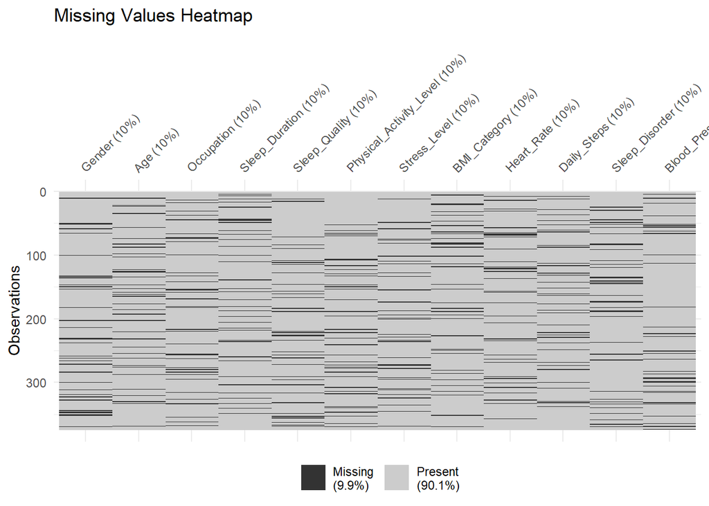

```r
# Visualize missingness
vis_miss(sleep) +
  labs(title = "Missing Values Heatmap")
```

From investigating the structure of the missingness there does not seem to be any patterns since the black parts which shows missing values are scattered randomly across present values. In this case missing completely at random (MCAR) can be suggested, but there is still possibility of mechanism being missing at random (MAR) if the missingness depends on another variable.

There are statistical tests for checking if the data has MCAR.

```r
library(MissMech)
sleep_numeric <- sleep[, sapply(sleep, is.numeric)]

TestMCARNormality(sleep_numeric)
```

```
## Call:
## TestMCARNormality(data = sleep_numeric)
##
## Number of Patterns:  6
##
## Total number of cases used in the analysis:  343
##
##  Pattern(s) used:
##           Age   Sleep_Duration   Physical_Activity_Level   Heart_Rate
## group.1     1                1                         1            1
## group.2     1               NA                         1            1
## group.3    NA                1                         1            1
## group.4     1                1                         1           NA
## group.5     1                1                         1            1
## group.6     1                1                        NA            1
##           Daily_Steps   Number of cases
## group.1             1               223
## group.2             1                27
## group.3             1                24
## group.4             1                23
## group.5            NA                24
## group.6             1                22
##
##
##     Test of normality and Homoscedasticity:
##   -------------------------------------------
##
## Hawkins Test:
##
##     P-value for the Hawkins test of normality and homoscedasticity:  0.0006487739
##
##     Either the test of multivariate normality or homoscedasticity (or both) is rejected.
##     Provided that normality can be assumed, the hypothesis of MCAR is
##     rejected at 0.05 significance level.
##
## Non-Parametric Test:
##
##     P-value for the non-parametric test of homoscedasticity:  0.08577937
##
##     Reject Normality at 0.05 significance level.
##     There is not sufficient evidence to reject MCAR at 0.05 significance level.
```

Hawkins rejects MCAR but it assumes normality, on the other hand non-parametric test fails to reject MCAR. As non-parametric test does not assume normality which the dataset violates, it can be concluded that the dataset has MCAR pattern.

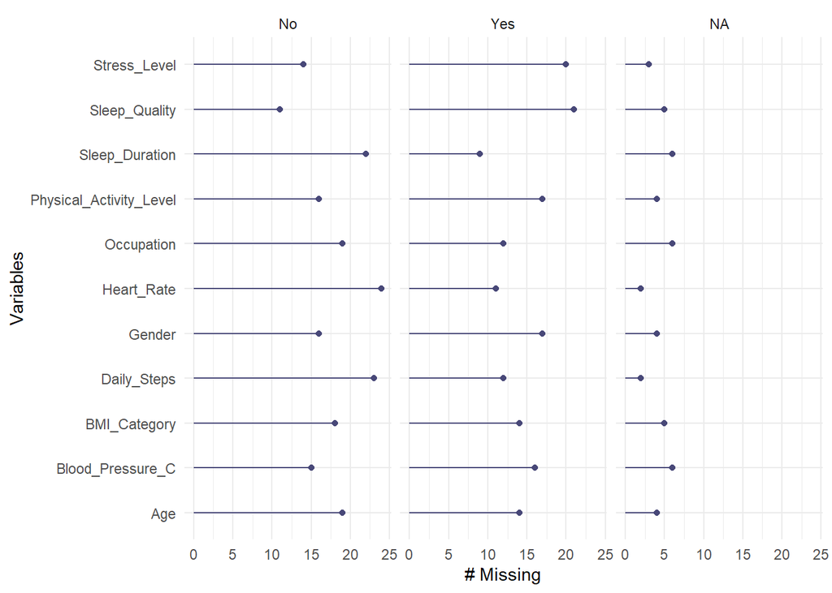

```r
gg_miss_var(sleep, facet=Sleep_Disorder)
```

When missing value pattern is considered with respect to having sleep disorder, it seems that there are no dependency on missingness across groups. This suggests MCAR once more as having a sleep disorder or not does not influence the number of missingness.

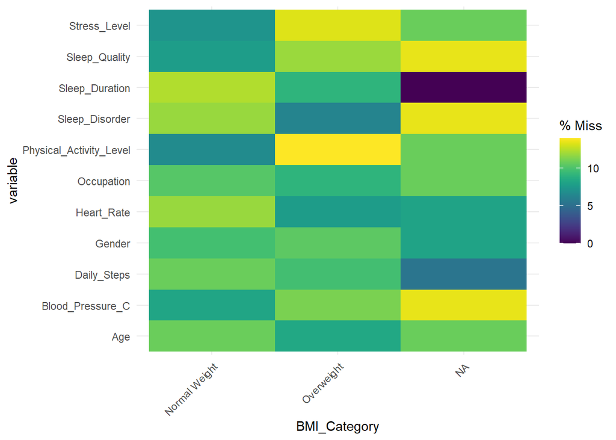

```r
gg_miss_fct(x = sleep, fct = BMI_Category)
```

There does not seem to be a pattern for BMI categories as well.

Now, as it is certain that the missingness comes from MCAR they can be imputed. Non-missing part of the data will be used to impute the missing part of the data.

```r
init = mice(sleep, maxit = 0, printFlag = FALSE)
default_methods = init$method
default_predMat = init$predictorMatrix

#default methods
print(default_methods)
```

```
##                  Gender                     Age              Occupation
##                "logreg"                   "pmm"               "polyreg"
##          Sleep_Duration           Sleep_Quality Physical_Activity_Level
##                   "pmm"               "polyreg"                   "pmm"
##            Stress_Level            BMI_Category              Heart_Rate
##               "polyreg"                "logreg"                   "pmm"
##             Daily_Steps          Sleep_Disorder        Blood_Pressure_C
##                   "pmm"                "logreg"               "polyreg"
```

From above the default methods for each variable can be seen.

```r
sleep_imp = mice(sleep, m = 5, maxit = 3, seed = 500)
summary(sleep_imp)
```

```
## Class: mids
## Number of multiple imputations:  5
## Imputation methods:
##                  Gender                     Age              Occupation
##                "logreg"                   "pmm"               "polyreg"
##          Sleep_Duration           Sleep_Quality Physical_Activity_Level
##                   "pmm"               "polyreg"                   "pmm"
##            Stress_Level            BMI_Category              Heart_Rate
##               "polyreg"                "logreg"                   "pmm"
##             Daily_Steps          Sleep_Disorder        Blood_Pressure_C
##                   "pmm"                "logreg"               "polyreg"
## PredictorMatrix:
##                         Gender Age Occupation Sleep_Duration Sleep_Quality
## Gender                       0   1          1              1             1
## Age                          1   0          1              1             1
## Occupation                   1   1          0              1             1
## Sleep_Duration               1   1          1              0             1
## Sleep_Quality                1   1          1              1             0
## Physical_Activity_Level      1   1          1              1             1
##                         Physical_Activity_Level Stress_Level BMI_Category
## Gender                                        1            1            1
## Age                                           1            1            1
## Occupation                                    1            1            1
## Sleep_Duration                                1            1            1
## Sleep_Quality                                 1            1            1
## Physical_Activity_Level                       0            1            1
##                         Heart_Rate Daily_Steps Sleep_Disorder Blood_Pressure_C
## Gender                           1           1              1                1
## Age                              1           1              1                1
## Occupation                       1           1              1                1
## Sleep_Duration                   1           1              1                1
## Sleep_Quality                    1           1              1                1
## Physical_Activity_Level          1           1              1                1
## Number of logged events:  12
##   it im            dep   meth               out
## 1  1  2 Sleep_Disorder logreg OccupationManager
## 2  1  4 Sleep_Disorder logreg OccupationManager
## 3  1  5 Sleep_Disorder logreg OccupationManager
## 4  2  1 Sleep_Disorder logreg OccupationManager
## 5  2  2 Sleep_Disorder logreg OccupationManager
## 6  2  3 Sleep_Disorder logreg OccupationManager
```

```r
sleep_comp = complete(sleep_imp, 1)

sum(is.na(sleep_comp))
```

```
## [1] 0
```

There are no longer missing values in our dataset.

```r
summary(sleep)
```

```
##     Gender         Age             Occupation Sleep_Duration    Sleep_Quality
##  Female:164   Min.   :27.00   Nurse     :64   Min.   :5.800   Low      :  5
##  Male  :173   1st Qu.:35.00   Doctor    :63   1st Qu.:6.400   Moderate :104
##  NA's  : 37   Median :43.00   Engineer  :57   Median :7.200   Good     :166
##               Mean   :42.27   Lawyer    :39   Mean   :7.128   Very Good: 62
##               3rd Qu.:50.00   Accountant:36   3rd Qu.:7.800   NA's     : 37
##               Max.   :59.00   (Other)   :78   Max.   :8.500
##               NA's   :37      NA's      :37   NA's   :37
##  Physical_Activity_Level   Stress_Level        BMI_Category   Heart_Rate
##  Min.   :30.00           Low     : 63   Normal Weight:194   Min.   :65.00
##  1st Qu.:45.00           Moderate:171   Overweight   :143   1st Qu.:68.00
##  Median :60.00           High    :103   NA's         : 37   Median :70.00
##  Mean   :59.49           NA's    : 37                       Mean   :70.23
##  3rd Qu.:75.00                                              3rd Qu.:72.00
##  Max.   :90.00                                              Max.   :86.00
##  NA's   :37                                                 NA's   :37
##   Daily_Steps    Sleep_Disorder     Blood_Pressure_C
##  Min.   : 3000   No  :192       High Stage 1:237
##  1st Qu.: 6000   Yes :145       High Stage 2: 59
##  Median : 7000   NA's: 37       Moderate    : 41
##  Mean   : 6821                  NA's        : 37
##  3rd Qu.: 8000
##  Max.   :10000
##  NA's   :37
```

```r
summary(sleep_comp)
```

```
##     Gender         Age             Occupation Sleep_Duration    Sleep_Quality
##  Female:185   Min.   :27.00   Nurse     :76   Min.   :5.800   Low      :  5
##  Male  :189   1st Qu.:35.25   Doctor    :70   1st Qu.:6.400   Moderate :111
##               Median :43.00   Engineer  :65   Median :7.200   Good     :187
##               Mean   :42.22   Lawyer    :43   Mean   :7.132   Very Good: 71
##               3rd Qu.:50.00   Teacher   :38   3rd Qu.:7.800
##               Max.   :59.00   Accountant:37   Max.   :8.500
##                               (Other)   :45
##  Physical_Activity_Level   Stress_Level        BMI_Category   Heart_Rate
##  Min.   :30.0            Low     : 70   Normal Weight:215   Min.   :65.00
##  1st Qu.:45.0            Moderate:183   Overweight   :159   1st Qu.:68.00
##  Median :60.0            High    :121                       Median :70.00
##  Mean   :59.5                                               Mean   :70.21
##  3rd Qu.:75.0                                               3rd Qu.:72.00
##  Max.   :90.0                                               Max.   :86.00
##
##   Daily_Steps    Sleep_Disorder     Blood_Pressure_C
##  Min.   : 3000   No :217        High Stage 1:261
##  1st Qu.: 5500   Yes:157        High Stage 2: 71
##  Median : 7000                  Moderate    : 42
##  Mean   : 6776
##  3rd Qu.: 8000
##  Max.   :10000
##
```

When we compare imputed and raw data, there can be seen some differences. Still there are more male participants than female participants but as expected both has increased. The range of age did not change but mean is no longer 42.27, it became 42.22. When occupation is observed, number of nurses increased to 76, number of of doctors increased to 70 etc. The mean of sleep duration changed from 7.128 to 7.132, the average slightly increased but range did not differ. The order of sleep quality levels, stress levels, BMI categories, and blood pressure categories did not change. Physical activity level did not change at all, there is a 0.01 increase in mean. The average of heart rate changed from 70.23 to 70.21. The mean of daily steps were 6821, it decreased to 67776. Lastly, the number of participants who do not have a sleep disease increased to 217 from 192, and who have a sleep disease increased to 157 from 145.

Hence, neither the ranges nor medians changed in continuous variables.

Original Sleep_Quality proportions:

```r
prop.table(table(sleep[["Sleep_Quality"]]))
```

```
##
##       Low  Moderate      Good Very Good
## 0.0148368 0.3086053 0.4925816 0.1839763
```

Imputed Sleep_Quality proportions:

```r
prop.table(table(sleep_comp[["Sleep_Quality"]]))
```

```
##
##        Low   Moderate       Good  Very Good
## 0.01336898 0.29679144 0.50000000 0.18983957
```

It can be seen that the proportion varied very subtly. While proportion of good and very good sleep quality increased very little, low and moderate decreased.

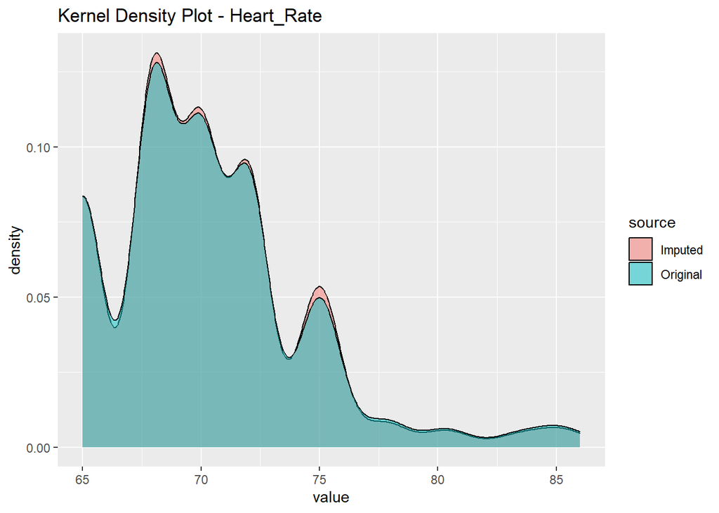

```r
for (var in names(sleep)[9]) { #can be used for more than 1 variable, thus I used for loop just in case
  df <- data.frame(
    value = c(sleep[[var]], sleep_comp[[var]]),
    source = rep(c("Original", "Imputed"), each = nrow(sleep))
  )

  p <- ggplot(df, aes(x = value, fill = source)) +
    geom_density(alpha = 0.5) +
    ggtitle(paste("Kernel Density Plot -", var))

  print(p)
}
```

When kernel density plot of heart rate is observed it is seen that imputed and original data overlays, which is good. Same results were obtained from other continuous variables.

# Feature Engineering and Data Manipulation

In the beginning of the project some of the variables were altered to enable EDA such as sleep quality, stress level, BMI category, blood pressure and sleep disorder. Sleep quality was a score between 1-10, it was modified to be Low-Moderate-Good-Very Good as there were empty scores. Stress level was also a score between 1-10, it was altered to be Low-Moderate-High. BMI categories were problematic as it contained normal, normal weight, overweight and obese; normal&normal weight and overweight&obese classes were merged. Sleep disorder was modified to a binary factor variable to show not having a sleep disorder and having a sleep disorder (insomnia or sleep apnea). Blood pressure variable was a character which showed “systolic pressure/diastolic pressure”, it was divided into two columns and separated into blood pressure categories.

# Confirmatory Data Analysis

As there are many questions, some of them are chosen to analyse further.

#### Q1: How are the sleep disorder distributed?

Let us check it the sleep disorder has normal distribution.

```r
chisquare_q1 <- chisq.test(table(sleep_comp$Sleep_Disorder))
chisquare_q1$expected
```

```
##  No Yes
## 187 187
```

```r
chisquare_q1
```

```
##
##  Chi-squared test for given probabilities
##
## data:  table(sleep_comp$Sleep_Disorder)
## X-squared = 9.6257, df = 1, p-value = 0.001919
```

Since expected counts of chi square test are greater than 1 it can be used. Since the p-value is less than 0.05 we reject the null hypothesis which means that the sleep disorders variable is not normally distributed.

#### Q2: How are the ages of participants distributed?

Let us see if the age follows a normal distribution.

```r
shapiro.test(sleep_comp$Age)
```

```
##
##  Shapiro-Wilk normality test
##
## data:  sleep_comp$Age
## W = 0.95897, p-value = 1.023e-08
```

Since the p-value of Shapiro-Wilk test is much less than 0.05, the null hypothesis is rejected which means data is not normally distributed.

Skewness and kurtosis can also be checked:

```r
skewness(sleep_comp$Age)
```

```
## [1] 0.2370863
```

```r
kurtosis(sleep_comp$Age)
```

```
## [1] -0.9217595
```

Skewness should be around 0 and kurtosis should be around -3 or 3. The skewness of age is good but kurtosis is far from -3. It still does not seem normal.

#### Q5: What is the relationship between sleep disorders and physical activity level?

First, we need to check the normality.

```r
by(sleep_comp$Physical_Activity_Level, sleep_comp$Sleep_Disorder, shapiro.test)
```

```
## sleep_comp$Sleep_Disorder: No
##
##  Shapiro-Wilk normality test
##
## data:  dd[x, ]
## W = 0.87517, p-value = 2.248e-12
##
## ------------------------------------------------------------
## sleep_comp$Sleep_Disorder: Yes
##
##  Shapiro-Wilk normality test
##
## data:  dd[x, ]
## W = 0.8383, p-value = 7.004e-12
```

From the shapiro-wilk test we can see that normality is not satisfied. Non-parametric tests can be used in this case.

Let us check the homoscedasticity anyways.

```r
leveneTest(Physical_Activity_Level ~ Sleep_Disorder, data = sleep_comp)
```

```
## Levene's Test for Homogeneity of Variance (center = median)
##        Df F value  Pr(>F)
## group   1   3.636 0.05731 .
##       372
## ---
## Signif. codes:  0 '***' 0.001 '**' 0.01 '*' 0.05 '.' 0.1 ' ' 1
```

Since the p-value of Levene’s test is greater than 0.05 the homoscedasticity of variance assumption is satisfied.

Wilcoxon Rank-Sum test can be used since the normality is not satisfied.

```r
wilcox.test(Physical_Activity_Level ~ Sleep_Disorder, data = sleep_comp)
```

```
##
##  Wilcoxon rank sum test with continuity correction
##
## data:  Physical_Activity_Level by Sleep_Disorder
## W = 15011, p-value = 0.04656
## alternative hypothesis: true location shift is not equal to 0
```

When the output of Wilcoxon-Rank-Sum test is observed, the p-value is 0.046. Even though it is very close to 0.05, it is still a bit smaller so null hypothesis can be rejected. Hence, there is a significant difference in the physical activity levels in a day between having a sleep disorder or not. From the previous violin plot we’ve already seen that participants who have sleep disorders have lower median in physical activity amount in a day.

#### Q6:What is the relationship between BMI categories and stress levels of attendants?

Chi-Square test can be applied but assumptions should be checked as well.

```r
q6_table <- table(sleep_comp$BMI_Category, sleep_comp$Stress_Level)
chisq_results <- chisq.test(q6_table)
```

```r
chisq_results$expected
```

```
##
##                      Low  Moderate     High
##   Normal Weight 40.24064 105.20053 69.55882
##   Overweight    29.75936  77.79947 51.44118
```

Since none of the expected counts are below 1 chi-square test is valid to use.

```r
chisq_results
```

```
##
##  Pearson's Chi-squared test
##
## data:  q6_table
## X-squared = 61.481, df = 2, p-value = 4.463e-14
```

From the p-value of the Chi-Sq test we reject the null hypothesis as p-value is less that 0.05. Therefore, there is a significant association between BMI categories and stress levels. This association was also seen in the EDA visualization as the mosaic plot showed that while more overweight participants have high stress level than normal weighted ones, it is the opposite for moderate stress type.

# MODELING

## Train Test Split

```r
set.seed(412)

sample_data = createDataPartition(sleep_comp$Sleep_Disorder, p = 0.8, list = FALSE)

#training dataset
train_sleep  = sleep_comp[sample_data, ]

#testing dataset
test_sleep = sleep_comp[-sample_data, ]
```

Check the frequency:

```r
table(train_sleep$Sleep_Disorder)
```

```
##
##  No Yes
## 174 126
```

```r
prop.table(table(train_sleep$Sleep_Disorder))
```

```
##
##   No  Yes
## 0.58 0.42
```

```r
prop.table(table(test_sleep$Sleep_Disorder))
```

```
##
##        No       Yes
## 0.5810811 0.4189189
```

The same proportions are reserved with respect to the original data.

## Multiple Logistic Regression

Check multicollinearity:

```r
cor(train_sleep[,c(2,4,6,9,10)])
```

```
##                                 Age Sleep_Duration Physical_Activity_Level
## Age                      1.00000000     0.33148745               0.2154588
## Sleep_Duration           0.33148745     1.00000000               0.1801330
## Physical_Activity_Level  0.21545878     0.18013304               1.0000000
## Heart_Rate              -0.21563710    -0.50567356               0.1655274
## Daily_Steps              0.07582718    -0.08384923               0.7418682
##                          Heart_Rate Daily_Steps
## Age                     -0.21563710  0.07582718
## Sleep_Duration          -0.50567356 -0.08384923
## Physical_Activity_Level  0.16552738  0.74186817
## Heart_Rate               1.00000000 -0.03282139
## Daily_Steps             -0.03282139  1.00000000
```

Daily steps and physical activity level has 0.74 correlation which can cause multicollinearity. But there is only one pair close to 0.8, it does not seem necessary to use PCA at this rate.

```r
glm_model <- glm(Sleep_Disorder ~ ., data = train_sleep, family = binomial)

print(summary(glm_model))
```

```
##
## Call:
## glm(formula = Sleep_Disorder ~ ., family = binomial, data = train_sleep)
##
## Deviance Residuals:
##     Min       1Q   Median       3Q      Max
## -2.7051  -0.3318  -0.2398   0.2397   2.6596
##
## Coefficients:
##                                  Estimate Std. Error z value Pr(>|z|)
## (Intercept)                    -2.474e+01  1.072e+04  -0.002    0.998
## GenderMale                     -9.790e-01  1.805e+00  -0.543    0.587
## Age                            -2.729e-02  1.208e-01  -0.226    0.821
## OccupationDoctor               -2.322e+00  2.960e+00  -0.785    0.433
## OccupationEngineer             -1.850e+00  2.744e+00  -0.674    0.500
## OccupationLawyer               -1.581e+00  2.739e+00  -0.577    0.564
## OccupationManager               1.782e+01  7.579e+03   0.002    0.998
## OccupationNurse                -1.498e+00  2.841e+00  -0.527    0.598
## OccupationSales Representative -1.565e+01  1.164e+04  -0.001    0.999
## OccupationSalesperson           1.873e+01  2.194e+03   0.009    0.993
## OccupationScientist            -3.965e+00  1.271e+04   0.000    1.000
## OccupationSoftware Engineer    -1.756e+01  6.529e+03  -0.003    0.998
## OccupationTeacher               2.370e+00  1.585e+00   1.496    0.135
## Sleep_Duration                  7.003e-01  1.743e+00   0.402    0.688
## Sleep_QualityModerate          -2.964e+01  9.233e+03  -0.003    0.997
## Sleep_QualityGood              -1.157e+01  9.831e+03  -0.001    0.999
## Sleep_QualityVery Good          4.281e+00  1.072e+04   0.000    1.000
## Physical_Activity_Level         1.626e-02  3.999e-02   0.407    0.684
## Stress_LevelModerate            1.593e+01  4.283e+03   0.004    0.997
## Stress_LevelHigh                3.530e+01  5.455e+03   0.006    0.995
## BMI_CategoryOverweight          1.232e+00  1.573e+00   0.783    0.434
## Heart_Rate                      2.224e-01  1.544e-01   1.440    0.150
## Daily_Steps                    -6.261e-05  3.789e-04  -0.165    0.869
## Blood_Pressure_CHigh Stage 2    2.463e+00  3.412e+00   0.722    0.470
## Blood_Pressure_CModerate       -2.856e+00  2.099e+00  -1.360    0.174
##
## (Dispersion parameter for binomial family taken to be 1)
##
##     Null deviance: 408.18  on 299  degrees of freedom
## Residual deviance: 127.89  on 275  degrees of freedom
## AIC: 177.89
##
## Number of Fisher Scoring iterations: 18
```

```r
vif(glm_model)
```

```
##                                 GVIF Df GVIF^(1/(2*Df))
## Gender                  1.345088e+01  1        3.667544
## Age                     2.315069e+01  1        4.811517
## Occupation              8.223470e+03 10        1.569469
## Sleep_Duration          3.004171e+01  1        5.481031
## Sleep_Quality           6.034912e+15  3      426.689370
## Physical_Activity_Level 1.158510e+01  1        3.403689
## Stress_Level            1.633665e+15  2     6357.564316
## BMI_Category            1.076381e+01  1        3.280825
## Heart_Rate              5.920922e+00  1        2.433295
## Daily_Steps             5.331957e+00  1        2.309103
## Blood_Pressure_C        1.791382e+02  2        3.658449
```

From the logistic regression we can see that there is a problem since all of the variables are insignificant, even though the median seems good as it is around 0. VIF values can be checked to see which variables are causing the problem and if there is a multicollinearity problem. VIF values above 5 or 10 can be a candidate, in this case variables are greater than 10, there is a multicollinearity problem, lets remove Sleep_Quality and Stress_Level variables and fit again as they have the greatest GVIF^(1/(2*Df)). Also, we have seen from the correlation plot that Daily_Steps and Physical_Activity_Level likely has multicollinearity, thus Daily_Steps is also removed (after many combinations and trial errors).

```r
glm_model2 <- glm(Sleep_Disorder ~ Gender + Age + Occupation + Sleep_Duration + Physical_Activity_Level +
                        BMI_Category + Heart_Rate + Blood_Pressure_C, data = train_sleep, family = binomial)

print(summary(glm_model2))
```

```
##
## Call:
## glm(formula = Sleep_Disorder ~ Gender + Age + Occupation + Sleep_Duration +
##     Physical_Activity_Level + BMI_Category + Heart_Rate + Blood_Pressure_C,
##     family = binomial, data = train_sleep)
##
## Deviance Residuals:
##     Min       1Q   Median       3Q      Max
## -2.7277  -0.3320  -0.2407   0.2252   2.6997
##
## Coefficients:
##                                  Estimate Std. Error z value Pr(>|z|)
## (Intercept)                    -2.884e+01  1.040e+01  -2.774  0.00553 **
## GenderMale                     -7.391e-01  1.616e+00  -0.457  0.64732
## Age                             1.675e-02  9.194e-02   0.182  0.85543
## OccupationDoctor               -3.711e+00  2.442e+00  -1.520  0.12849
## OccupationEngineer             -3.209e+00  2.054e+00  -1.562  0.11825
## OccupationLawyer               -3.375e+00  2.277e+00  -1.482  0.13827
## OccupationManager               1.512e+01  4.610e+03   0.003  0.99738
## OccupationNurse                -3.993e+00  2.408e+00  -1.658  0.09726 .
## OccupationSales Representative  8.186e+00  4.180e+03   0.002  0.99844
## OccupationSalesperson           1.721e+01  1.331e+03   0.013  0.98969
## OccupationScientist            -4.765e+00  2.413e+00  -1.975  0.04825 *
## OccupationSoftware Engineer    -5.557e+00  8.327e+00  -0.667  0.50454
## OccupationTeacher               2.004e+00  1.407e+00   1.424  0.15454
## Sleep_Duration                  3.413e-01  5.619e-01   0.608  0.54351
## Physical_Activity_Level         2.944e-03  1.884e-02   0.156  0.87581
## BMI_CategoryOverweight          6.368e-02  1.365e+00   0.047  0.96278
## Heart_Rate                      3.865e-01  1.179e-01   3.278  0.00105 **
## Blood_Pressure_CHigh Stage 2    4.280e+00  2.429e+00   1.762  0.07811 .
## Blood_Pressure_CModerate       -4.201e+00  1.965e+00  -2.138  0.03248 *
## ---
## Signif. codes:  0 '***' 0.001 '**' 0.01 '*' 0.05 '.' 0.1 ' ' 1
##
## (Dispersion parameter for binomial family taken to be 1)
##
##     Null deviance: 408.18  on 299  degrees of freedom
## Residual deviance: 134.85  on 281  degrees of freedom
## AIC: 172.85
##
## Number of Fisher Scoring iterations: 17
```

```r
vif(glm_model2)
```

```
##                                GVIF Df GVIF^(1/(2*Df))
## Gender                    11.301986  1        3.361843
## Age                       14.176669  1        3.765192
## Occupation              1082.756814 10        1.418164
## Sleep_Duration             3.578875  1        1.891791
## Physical_Activity_Level    2.821564  1        1.679751
## BMI_Category               8.639387  1        2.939283
## Heart_Rate                 4.425702  1        2.103735
## Blood_Pressure_C          76.660268  2        2.958984
```

We can see that the GVIF values have gotten much better, let us remove Occupation as well to see if multicollinearity problem can be solved finally.

```r
glm_model3 <- glm(Sleep_Disorder ~Gender + Age + Sleep_Duration + Physical_Activity_Level +
                        BMI_Category + Heart_Rate + Blood_Pressure_C, data = train_sleep, family = binomial)

print(summary(glm_model3))
```

```
##
## Call:
## glm(formula = Sleep_Disorder ~ Gender + Age + Sleep_Duration +
##     Physical_Activity_Level + BMI_Category + Heart_Rate + Blood_Pressure_C,
##     family = binomial, data = train_sleep)
##
## Deviance Residuals:
##     Min       1Q   Median       3Q      Max
## -2.7282  -0.3621  -0.2874   0.4626   2.5301
##
## Coefficients:
##                                Estimate Std. Error z value Pr(>|z|)
## (Intercept)                  -11.620807   6.511744  -1.785   0.0743 .
## GenderMale                     0.054528   0.623698   0.087   0.9303
## Age                            0.069351   0.051649   1.343   0.1794
## Sleep_Duration                -0.579377   0.475019  -1.220   0.2226
## Physical_Activity_Level        0.003831   0.014076   0.272   0.7855
## BMI_CategoryOverweight         3.444395   0.669738   5.143 2.71e-07 ***
## Heart_Rate                     0.149016   0.070051   2.127   0.0334 *
## Blood_Pressure_CHigh Stage 2   0.361149   0.829117   0.436   0.6631
## Blood_Pressure_CModerate      -0.166586   0.912684  -0.183   0.8552
## ---
## Signif. codes:  0 '***' 0.001 '**' 0.01 '*' 0.05 '.' 0.1 ' ' 1
##
## (Dispersion parameter for binomial family taken to be 1)
##
##     Null deviance: 408.18  on 299  degrees of freedom
## Residual deviance: 166.54  on 291  degrees of freedom
## AIC: 184.54
##
## Number of Fisher Scoring iterations: 6
```

```r
vif(glm_model3)
```

```
##                             GVIF Df GVIF^(1/(2*Df))
## Gender                  2.240236  1        1.496742
## Age                     4.636502  1        2.153254
## Sleep_Duration          3.034237  1        1.741906
## Physical_Activity_Level 1.800845  1        1.341956
## BMI_Category            2.574446  1        1.604508
## Heart_Rate              1.863255  1        1.365011
## Blood_Pressure_C        3.296919  2        1.347495
```

Now, there is no longer multicollinearity problem. We can just keep significant variables in the model at this point to be able to interpret.

```r
glm_model4 <- glm(Sleep_Disorder ~ BMI_Category + Heart_Rate , data = train_sleep, family = binomial)

print(summary(glm_model4))
```

```
##
## Call:
## glm(formula = Sleep_Disorder ~ BMI_Category + Heart_Rate, family = binomial,
##     data = train_sleep)
##
## Deviance Residuals:
##     Min       1Q   Median       3Q      Max
## -2.4936  -0.3899  -0.2642   0.4446   2.4142
##
## Coefficients:
##                         Estimate Std. Error z value Pr(>|z|)
## (Intercept)            -13.72226    3.82482  -3.588 0.000334 ***
## BMI_CategoryOverweight   4.48385    0.41699  10.753  < 2e-16 ***
## Heart_Rate               0.15976    0.05421   2.947 0.003209 **
## ---
## Signif. codes:  0 '***' 0.001 '**' 0.01 '*' 0.05 '.' 0.1 ' ' 1
##
## (Dispersion parameter for binomial family taken to be 1)
##
##     Null deviance: 408.18  on 299  degrees of freedom
## Residual deviance: 170.30  on 297  degrees of freedom
## AIC: 176.3
##
## Number of Fisher Scoring iterations: 5
```

```r
vif(glm_model4)
```

```
## BMI_Category   Heart_Rate
##     1.014724     1.014724
```

Being overweight compared to normal weight increases log-odds by 4.48, overweight people are 88.5 times more likely to have a sleep disorder than normal weight people assuming all other are equal. One unit increase in heart rate increases 17% increase in odds of having sleep disorders.

Scaling was applied to solve multicollinearity but it did not solve the problem.

# Model Performance

```r
predicted_probs_train <- predict(glm_model4, newdata = train_sleep, type = "response")
actual_train <- ifelse(train_sleep$Sleep_Disorder == "Yes", 1, 0)
```

```r
predicted_probs_test <- predict(glm_model4, newdata = test_sleep, type = "response")
actual_test <- ifelse(test_sleep$Sleep_Disorder == "Yes", 1, 0)
```

```r
roc_glm_train <- roc(actual_train, predicted_probs_train)
```

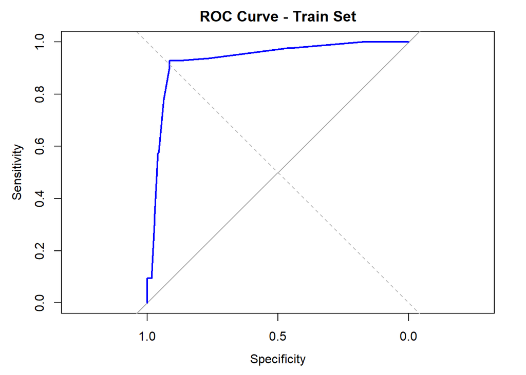

```r
plot(roc_glm_train, col = "blue", lwd = 2, main = "ROC Curve - Train Set")
abline(a = 0, b = 1, lty = 2, col = "gray")
```

```r
roc_glm_test <- roc(actual_test, predicted_probs_test)
```

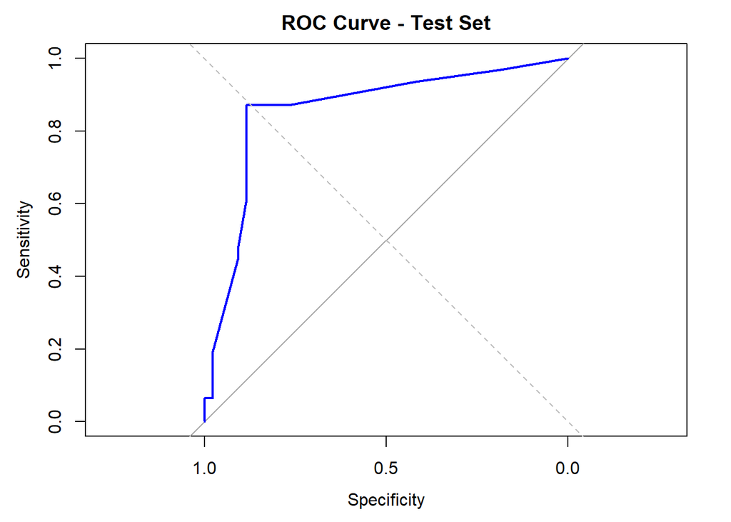

```r
plot(roc_glm_test, col = "blue", lwd = 2, main = "ROC Curve - Test Set")
abline(a = 0, b = 1, lty = 2, col = "gray")
```

```r
# Show AUC
cat("train:",auc(roc_glm_train),
    "\n", "test:",auc(roc_glm_test))
```

```
## train: 0.9306924
##  test: 0.8574644
```

Area under the curve shows the performance of how good the model can separate the two classes. 0.93 is a really good number. Test gives 0.85 which is also good there does not seem to be a serious overfit but it should be kept in mind.

```r
#training set prediction
train_probabilities1 <- predict(glm_model4, newdata = train_sleep, type = "response")
train_predictions1 <- factor(ifelse(train_probabilities1 > 0.5, "Yes", "No"), levels = c("No", "Yes"))

#test set prediction
test_probabilities1 <- predict(glm_model4, newdata = test_sleep, type = "response")
test_predictions1 <- factor(ifelse(test_probabilities1 > 0.5, "Yes", "No"), levels = c("No", "Yes"))

#actual values
actual_train1 <- factor(train_sleep$Sleep_Disorder, levels = c("No", "Yes"))
actual_test1  <- factor(test_sleep$Sleep_Disorder,  levels = c("No", "Yes"))

#Confusion matrices
train_conf <- confusionMatrix(train_predictions1, actual_train1, positive = "Yes")
test_conf <- confusionMatrix(test_predictions1, actual_test1, positive = "Yes")

cat("TRAIN PERFORMANCE:\n")
```

```
## TRAIN PERFORMANCE:
```

```r
print(train_conf)
```

```
## Confusion Matrix and Statistics
##
##           Reference
## Prediction  No Yes
##        No  159  12
##        Yes  15 114
##
##                Accuracy : 0.91
##                  95% CI : (0.8718, 0.9399)
##     No Information Rate : 0.58
##     P-Value [Acc > NIR] : <2e-16
##
##                   Kappa : 0.8159
##
##  Mcnemar's Test P-Value : 0.7003
##
##             Sensitivity : 0.9048
##             Specificity : 0.9138
##          Pos Pred Value : 0.8837
##          Neg Pred Value : 0.9298
##              Prevalence : 0.4200
##          Detection Rate : 0.3800
##    Detection Prevalence : 0.4300
##       Balanced Accuracy : 0.9093
##
##        'Positive' Class : Yes
##
```

```r
cat("\nTEST PERFORMANCE:\n")
```

```
##
## TEST PERFORMANCE:
```

```r
print(test_conf)
```

```
## Confusion Matrix and Statistics
##
##           Reference
## Prediction No Yes
##        No  38   6
##        Yes  5  25
##
##                Accuracy : 0.8514
##                  95% CI : (0.7496, 0.9234)
##     No Information Rate : 0.5811
##     P-Value [Acc > NIR] : 5.317e-07
##
##                   Kappa : 0.6933
##
##  Mcnemar's Test P-Value : 1
##
##             Sensitivity : 0.8065
##             Specificity : 0.8837
##          Pos Pred Value : 0.8333
##          Neg Pred Value : 0.8636
##              Prevalence : 0.4189
##          Detection Rate : 0.3378
##    Detection Prevalence : 0.4054
##       Balanced Accuracy : 0.8451
##
##        'Positive' Class : Yes
##
```

When accuracy of the train set is checked it is seen that 91% of the overall predictions are correct, it is higher compared to the test set which can indicate mild overfitting. Sensitivity, which shows correctly classified true cases is good on both cases, but it is again high on train set. Specificity is the percentage of correctly classified false cases, which is 91% on train and 88% on test set. When no information rate is checked it is observed that the cases which are no are 58% of the samples in both sets. Also, the low p-value shows that the model is significantly better than the NIR. Lastly, Kappa value shows that the model is good, train set is a little higher might show overfitting.

Generally, confusion matrix results are good on both cases. It should be kept in mind that higher train accuracy might indicate overfitting but it does not seem severe.